# York and Diming Regression

Quan Gan

2/26/2022

## Load data in

There are three data sets with low, intermediate, and high errors.

```r
data_low <- read_csv("../Data/Dataset_S1.csv")
data_intermediate <- read_csv("../Data/Dataset_S2.csv")
data_high <- read_csv("../Data/Dataset_S3.csv")
```

## The functions for bootstrapping 1000 replicates with York models

```r
# https://www.statmethods.net/advstats/bootstrapping.html
# Boot library docs
# calculate the Intercept
York_model <- function(data, indices) {
  d <- data[indices,]                   # allows boot to select sample
  mark <- sample(                       # Mark for train-test
    c(rep(0, 0.7*nrow(d)),
    c(rep(1, 0.3*nrow(d)))))
  train <- d[mark == 0,]                # train data
  test <- d[mark == 1,]                 # test data
  york_data <- cbind(train$Temperature, train$TempError, train$D47, train$D47error)
  fit <- york(york_data)                # the York model
  Intercept <- fit$a['a']
  Slope <- fit$b['b']
  train_MSE <- mean((train$D47 - (train$Temperature * Slope + Intercept))^2)  # Train set MSE
  test_MSE <- mean((test$D47 - (test$Temperature * Slope + Intercept))^2) # Test set MSE
  return(c(Intercept, Slope, train_MSE, test_MSE))                    # get intercept
}

Deming_model <- function(formula, data, indices) {
  d <- data[indices,]                   # allows boot to select sample
  mark <- sample(                       # Mark for train-test
    c(rep(0, 0.7*nrow(d)),
    c(rep(1, 0.3*nrow(d)))))
  train <- d[mark == 0,]                # train data
  test <- d[mark == 1,]                 # test data
  fit <- deming(formula, data=train, xstd=abs(TempError), ystd=abs(D47error))    # the Deming model
  Intercept <- fit$coefficients[1]
  Slope <- fit$coefficients[2]
  train_MSE <- mean((train$D47 - (train$Temperature * Slope + Intercept))^2)  # Train set MSE
  test_MSE <- mean((test$D47 - (test$Temperature * Slope + Intercept))^2) # Test set MSE
  return(c(Intercept, Slope, train_MSE, test_MSE))                    # get intercept
}
```

## York Regresion

Unified regression algorithm. Given n pairs of measurements of x and y with their uncertainties x_error, y_error. The york function finds the best straight line using the least-squares algorithm of York.

### Low error data

```r
# set seed for production
set.seed(1234)

# bootstrapping with 1000 replications
york_results_low <- boot(data=data_low,
                statistic=York_model,
                R=1000)


cat("Median Intercept:", median(york_results_low$t[,1]))
```

```
## Median Intercept: 0.2109326
```

```r
cat("Intercept Std. Error:", sd(york_results_low$t[,1]))
```

```
## Intercept Std. Error: 0.0435565
```

```r
cat("Meidan Slope:", median(york_results_low$t[,2]))
```

```
## Meidan Slope: 0.04167244
```

```r
cat("Slope Std. Error:", sd(york_results_low$t[,2]))
```

```
## Slope Std. Error: 0.003670694
```

```r
cat("Median Train MSE:", median(york_results_low$t[,3]))
```

```
## Median Train MSE: 0.0001969451
```

```r
cat("Meidan Test MSE:", median(york_results_low$t[,4]))
```

```
## Meidan Test MSE: 0.0001995229
```

```r
print(boot.ci(york_results_low, type="bca", index=1))
```

```
## BOOTSTRAP CONFIDENCE INTERVAL CALCULATIONS
## Based on 1000 bootstrap replicates
##
## CALL :
## boot.ci(boot.out = york_results_low, type = "bca", index = 1)
##
## Intervals :
## Level       BCa
## 95%   ( 0.1925,  0.3004 )
## Calculations and Intervals on Original Scale
## Warning : BCa Intervals used Extreme Quantiles
## Some BCa intervals may be unstable
```

```r
print(boot.ci(york_results_low, type="bca", index=2))
```

```
## BOOTSTRAP CONFIDENCE INTERVAL CALCULATIONS
## Based on 1000 bootstrap replicates
##
## CALL :
## boot.ci(boot.out = york_results_low, type = "bca", index = 2)
##
## Intervals :
## Level       BCa
## 95%   ( 0.0340,  0.0433 )
## Calculations and Intervals on Original Scale
## Warning : BCa Intervals used Extreme Quantiles
## Some BCa intervals may be unstable
```

#### Comparing result to the true parameters

Plot confident interval area of the median slope/intercept of bootstrapping results And comparing it to the true slope/intercept

I use the true data points to plot.

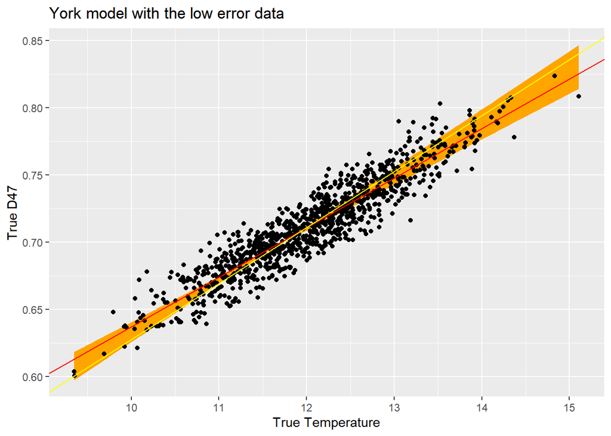

```r
data_low %>%
  ggplot(aes(x = x_TRUE, y=y_TRUE)) +
  geom_ribbon(aes(ymin = 0.0340 * x_TRUE + 0.3004  , ymax = 0.0433  * x_TRUE + 0.1925), fill = "orange") +
  geom_point() +
  geom_abline(slope = 0.0369, intercept = 0.268, color = 'red') +
  geom_abline(slope = median(york_results_low$t[,2]), intercept = median(york_results_low$t[,1]), color = 'yellow') +
  labs(title = "York model with the low error data") +
  xlab("True Temperature") +
  ylab("True D47")
```

### Intermediate error data

```r
# set seed for production
set.seed(1234)

# bootstrapping with 1000 replications
york_results_intermediate <- boot(data=data_intermediate,
                statistic=York_model,
                R=1000)


cat("Median Intercept:", median(york_results_intermediate$t[,1]))
```

```
## Median Intercept: 0.2193457
```

```r
cat("Intercept Std. Error:", sd(york_results_intermediate$t[,1]))
```

```
## Intercept Std. Error: 0.04609265
```

```r
cat("Meidan Slope:", median(york_results_intermediate$t[,2]))
```

```
## Meidan Slope: 0.04093753
```

```r
cat("Slope Std. Error:", sd(york_results_intermediate$t[,2]))
```

```
## Slope Std. Error: 0.003849794
```

```r
cat("Median Train MSE:", median(york_results_intermediate$t[,3]))
```

```
## Median Train MSE: 0.0006187306
```

```r
cat("Meidan Test MSE:", median(york_results_intermediate$t[,4]))
```

```
## Meidan Test MSE: 0.0006253945
```

```r
print(boot.ci(york_results_intermediate, type="bca", index=1))
```

```
## BOOTSTRAP CONFIDENCE INTERVAL CALCULATIONS
## Based on 1000 bootstrap replicates
##
## CALL :
## boot.ci(boot.out = york_results_intermediate, type = "bca", index = 1)
##
## Intervals :
## Level       BCa
## 95%   ( 0.1683,  0.3321 )
## Calculations and Intervals on Original Scale
## Some BCa intervals may be unstable
```

```r
print(boot.ci(york_results_intermediate, type="bca", index=2))
```

```
## BOOTSTRAP CONFIDENCE INTERVAL CALCULATIONS
## Based on 1000 bootstrap replicates
##
## CALL :
## boot.ci(boot.out = york_results_intermediate, type = "bca", index = 2)
##
## Intervals :
## Level       BCa
## 95%   ( 0.0316,  0.0455 )
## Calculations and Intervals on Original Scale
## Some BCa intervals may be unstable
```

#### Comparing result to the true parameters

Plot confident interval area of the median slope/intercept of bootstrapping results And comparing it to the true slope/intercept

I use the true data points to plot.

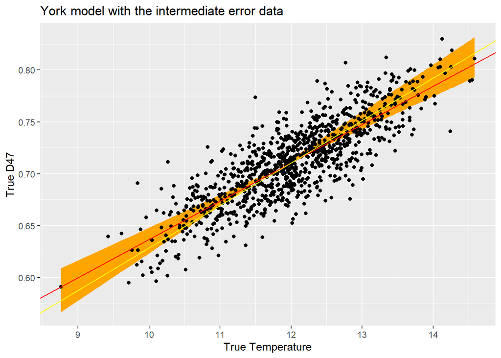

```r
data_intermediate %>%
  ggplot(aes(x = x_TRUE, y=y_TRUE)) +
  geom_ribbon(aes(ymin = 0.0316 * x_TRUE + 0.3321   , ymax = 0.0455   * x_TRUE + 0.1683), fill = "orange") +
  geom_point() +
  geom_abline(slope = 0.0369, intercept = 0.268, color = 'red') +
  geom_abline(slope = median(york_results_intermediate$t[,2]), intercept = median(york_results_intermediate$t[,1]), color = 'yellow') +
  labs(title = "York model with the intermediate error data") +
  xlab("True Temperature") +
  ylab("True D47")
```

### High error data

```r
# set seed for production
set.seed(1234)

# bootstrapping with 1000 replications
york_results_high <- boot(data=data_high,
                statistic=York_model,
                R=1000)


cat("Median Intercept:", median(york_results_high$t[,1]))
```

```
## Median Intercept: 0.1521774
```

```r
cat("Intercept Std. Error:", sd(york_results_high$t[,1]))
```

```
## Intercept Std. Error: 0.05779404
```

```r
cat("Meidan Slope:", median(york_results_high$t[,2]))
```

```
## Meidan Slope: 0.04674258
```

```r
cat("Slope Std. Error:", sd(york_results_high$t[,2]))
```

```
## Slope Std. Error: 0.004952868
```

```r
cat("Median Train MSE:", median(york_results_high$t[,3]))
```

```
## Median Train MSE: 0.001387571
```

```r
cat("Meidan Test MSE:", median(york_results_high$t[,4]))
```

```
## Meidan Test MSE: 0.001398425
```

```r
print(boot.ci(york_results_high, type="bca", index=1))
```

```
## BOOTSTRAP CONFIDENCE INTERVAL CALCULATIONS
## Based on 1000 bootstrap replicates
##
## CALL :
## boot.ci(boot.out = york_results_high, type = "bca", index = 1)
##
## Intervals :
## Level       BCa
## 95%   (-0.0610,  0.1889 )
## Calculations and Intervals on Original Scale
## Warning : BCa Intervals used Extreme Quantiles
## Some BCa intervals may be unstable
```

```r
print(boot.ci(york_results_high, type="bca", index=2))
```

```
## BOOTSTRAP CONFIDENCE INTERVAL CALCULATIONS
## Based on 1000 bootstrap replicates
##
## CALL :
## boot.ci(boot.out = york_results_high, type = "bca", index = 2)
##
## Intervals :
## Level       BCa
## 95%   ( 0.0435,  0.0644 )
## Calculations and Intervals on Original Scale
## Warning : BCa Intervals used Extreme Quantiles
## Some BCa intervals may be unstable
```

#### Comparing result to the true parameters

Plot confident interval area of the median slope/intercept of bootstrapping results And comparing it to the true slope/intercept

I use the true data points to plot.

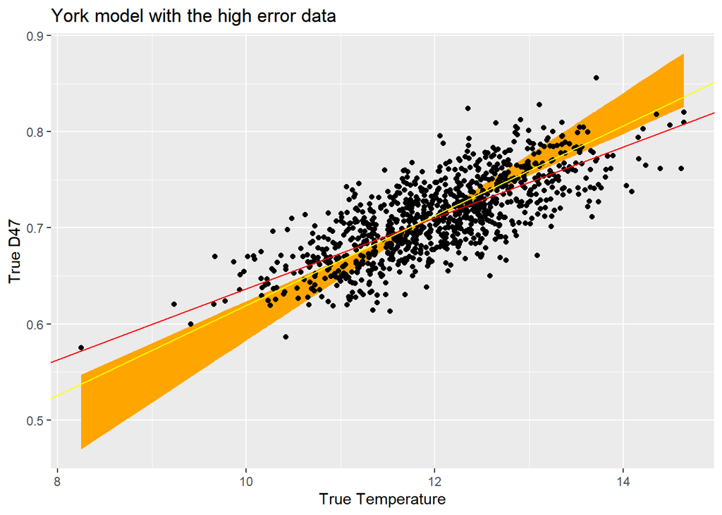

```r
data_high %>%
  ggplot(aes(x = x_TRUE, y=y_TRUE)) +
  geom_ribbon(aes(ymin = 0.0435 * x_TRUE + 0.1889    , ymax = 0.0644  * x_TRUE -0.0610), fill = "orange") +
  geom_point() +
  geom_abline(slope = 0.0369, intercept = 0.268, color = 'red') +
  geom_abline(slope = median(york_results_high$t[,2]), intercept = median(york_results_high$t[,1]), color = 'yellow') +
  labs(title = "York model with the high error data") +
  xlab("True Temperature") +
  ylab("True D47")
```

## Median slopes/intercepts VS true parameters

Mean slope/Intercept VS Median slope/Intercept

```r
medianIntercept <- c(median(york_results_low$t[,1]), median(york_results_intermediate$t[,1]), median(york_results_high$t[,1]))
sdIntercept <- c(sd(york_results_low$t[,1]), sd(york_results_intermediate$t[,1]), sd(york_results_high$t[,1]))
medianSlope <- c(median(york_results_low$t[,2]), median(york_results_intermediate$t[,2]), median(york_results_high$t[,2]))
sdSlope <- c(sd(york_results_low$t[,2]), sd(york_results_intermediate$t[,2]), sd(york_results_high$t[,2]))
medianTrainMSE <- c(median(york_results_low$t[,3]), median(york_results_intermediate$t[,3]), median(york_results_high$t[,3]))
medianTestMSE<- c(median(york_results_low$t[,4]), median(york_results_intermediate$t[,4]), median(york_results_high$t[,4]))

mat <- array(c(medianIntercept, sdIntercept, medianSlope, sdSlope, medianTrainMSE, medianTestMSE), dim = c(3, 6))
colnames(mat) <- c("median_Intercept", "sd_Intercept", "median_Slope", "sd_slope", "median_train_MSE", "median_test_MSE")
rownames(mat) <- c("Low Error", "Intermediate Error", "High Error")
mat %>%
  kable()
```

|  | median_Intercept | sd_Intercept | median_Slope | sd_slope | median_train_MSE | median_test_MSE |
| --- | --- | --- | --- | --- | --- | --- |
| Low Error | 0.2109326 | 0.0435565 | 0.0416724 | 0.0036707 | 0.0001969 | 0.0001995 |
| Intermediate Error | 0.2193457 | 0.0460926 | 0.0409375 | 0.0038498 | 0.0006187 | 0.0006254 |
| High Error | 0.1521774 | 0.0577940 | 0.0467426 | 0.0049529 | 0.0013876 | 0.0013984 |

## Deming Regression

Find the MLE line relating x and y when both are measured with error. When the variances of x and y are constant and equal, this is the special case of Deming regression.

### Low error data

```r
# set seed for production
set.seed(1234)

# bootstrapping with 1000 replications
deming_results_low <- boot(data=data_low,
                statistic=Deming_model,
                R=1000,
                formula=D47~Temperature)


cat("Median Intercept:", median(deming_results_low$t[,1]))
```

```
## Median Intercept: 0.2096746
```

```r
cat("Intercept Std. Error:", sd(deming_results_low$t[,1]))
```

```
## Intercept Std. Error: 0.04439524
```

```r
cat("Meidan Slope:", median(deming_results_low$t[,2]))
```

```
## Meidan Slope: 0.0417205
```

```r
cat("Slope Std. Error:", sd(deming_results_low$t[,2]))
```

```
## Slope Std. Error: 0.003748695
```

```r
cat("Median Train MSE:", median(deming_results_low$t[,3]))
```

```
## Median Train MSE: 0.0001977596
```

```r
cat("Meidan Test MSE:", median(deming_results_low$t[,4]))
```

```
## Meidan Test MSE: 0.0002001412
```

```r
print(boot.ci(deming_results_low, type="bca", index=1))
```

```
## BOOTSTRAP CONFIDENCE INTERVAL CALCULATIONS
## Based on 1000 bootstrap replicates
##
## CALL :
## boot.ci(boot.out = deming_results_low, type = "bca", index = 1)
##
## Intervals :
## Level       BCa
## 95%   ( 0.1897,  0.3005 )
## Calculations and Intervals on Original Scale
## Warning : BCa Intervals used Extreme Quantiles
## Some BCa intervals may be unstable
```

```r
print(boot.ci(deming_results_low, type="bca", index=2))
```

```
## BOOTSTRAP CONFIDENCE INTERVAL CALCULATIONS
## Based on 1000 bootstrap replicates
##
## CALL :
## boot.ci(boot.out = deming_results_low, type = "bca", index = 2)
##
## Intervals :
## Level       BCa
## 95%   ( 0.0340,  0.0435 )
## Calculations and Intervals on Original Scale
## Warning : BCa Intervals used Extreme Quantiles
## Some BCa intervals may be unstable
```

#### Comparing result to the true parameters

Plot confident interval area of the median slope/intercept of bootstrapping results And comparing it to the true slope/intercept

I use the true data points to plot.

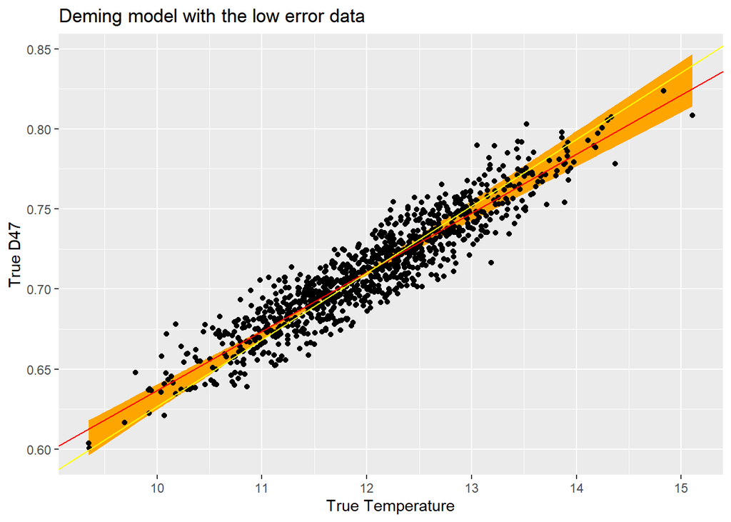

```r
data_low %>%
  ggplot(aes(x = x_TRUE, y=y_TRUE)) +
  geom_ribbon(aes(ymin = 0.0340 * x_TRUE + 0.3005  , ymax = 0.0435  * x_TRUE + 0.1897), fill = "orange") +
  geom_point() +
  geom_abline(slope = 0.0369, intercept = 0.268, color = 'red') +
  geom_abline(slope = median(deming_results_low$t[,2]), intercept = median(deming_results_low$t[,1]), color = 'yellow') +
  labs(title = "Deming model with the low error data") +
  xlab("True Temperature") +
  ylab("True D47")
```

### Intermediate error data

```r
# set seed for production
set.seed(1234)

# bootstrapping with 1000 replications
deming_results_intermediate <- boot(data=data_intermediate,
                statistic=Deming_model,
                R=1000,
                formula=D47~Temperature)


cat("Median Intercept:", median(deming_results_intermediate$t[,1]))
```

```
## Median Intercept: 0.2193577
```

```r
cat("Intercept Std. Error:", sd(deming_results_intermediate$t[,1]))
```

```
## Intercept Std. Error: 0.0598513
```

```r
cat("Meidan Slope:", median(deming_results_intermediate$t[,2]))
```

```
## Meidan Slope: 0.0409306
```

```r
cat("Slope Std. Error:", sd(deming_results_intermediate$t[,2]))
```

```
## Slope Std. Error: 0.004982807
```

```r
cat("Median Train MSE:", median(deming_results_intermediate$t[,3]))
```

```
## Median Train MSE: 0.0006187873
```

```r
cat("Meidan Test MSE:", median(deming_results_intermediate$t[,4]))
```

```
## Meidan Test MSE: 0.0006253363
```

```r
print(boot.ci(deming_results_intermediate, type="bca", index=1))
```

```
## BOOTSTRAP CONFIDENCE INTERVAL CALCULATIONS
## Based on 1000 bootstrap replicates
##
## CALL :
## boot.ci(boot.out = deming_results_intermediate, type = "bca",
##     index = 1)
##
## Intervals :
## Level       BCa
## 95%   ( 0.1684,  0.3397 )
## Calculations and Intervals on Original Scale
## Some BCa intervals may be unstable
```

```r
print(boot.ci(deming_results_intermediate, type="bca", index=2))
```

```
## BOOTSTRAP CONFIDENCE INTERVAL CALCULATIONS
## Based on 1000 bootstrap replicates
##
## CALL :
## boot.ci(boot.out = deming_results_intermediate, type = "bca",
##     index = 2)
##
## Intervals :
## Level       BCa
## 95%   ( 0.0314,  0.0455 )
## Calculations and Intervals on Original Scale
## Some BCa intervals may be unstable
```

#### Comparing result to the true parameters

Plot confident interval area of the median slope/intercept of bootstrapping results And comparing it to the true slope/intercept

I use the true data points to plot.

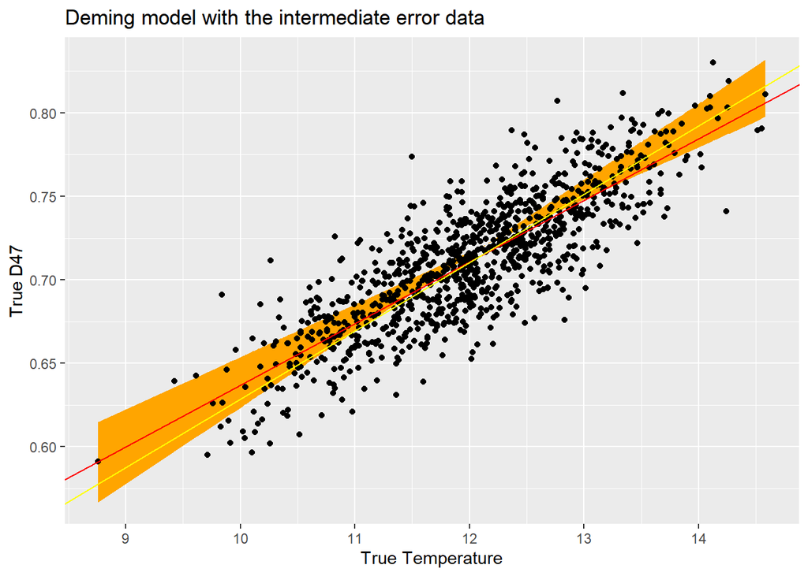

```r
data_intermediate %>%
  ggplot(aes(x = x_TRUE, y=y_TRUE)) +
  geom_ribbon(aes(ymin = 0.0314 * x_TRUE + 0.3397   , ymax = 0.0455  * x_TRUE + 0.1684), fill = "orange") +
  geom_point() +
  geom_abline(slope = 0.0369, intercept = 0.268, color = 'red') +
  geom_abline(slope = median(deming_results_intermediate$t[,2]), intercept = median(deming_results_intermediate$t[,1]), color = 'yellow') +
  labs(title = "Deming model with the intermediate error data") +
  xlab("True Temperature") +
  ylab("True D47")
```

### High error data

```r
# set seed for production
set.seed(1234)

# bootstrapping with 1000 replications
deming_results_high <- boot(data=data_high,
                statistic=Deming_model,
                R=1000,
                formula=D47~Temperature)


cat("Median Intercept:", median(deming_results_high$t[,1]))
```

```
## Median Intercept: 0.1521613
```

```r
cat("Intercept Std. Error:", sd(deming_results_high$t[,1]))
```

```
## Intercept Std. Error: 0.05777483
```

```r
cat("Meidan Slope:", median(deming_results_high$t[,2]))
```

```
## Meidan Slope: 0.04674256
```

```r
cat("Slope Std. Error:", sd(deming_results_high$t[,2]))
```

```
## Slope Std. Error: 0.004951346
```

```r
cat("Median Train MSE:", median(deming_results_high$t[,3]))
```

```
## Median Train MSE: 0.001387391
```

```r
cat("Meidan Test MSE:", median(deming_results_high$t[,4]))
```

```
## Meidan Test MSE: 0.001398402
```

```r
print(boot.ci(deming_results_high, type="bca", index=1))
```

```
## BOOTSTRAP CONFIDENCE INTERVAL CALCULATIONS
## Based on 1000 bootstrap replicates
##
## CALL :
## boot.ci(boot.out = deming_results_high, type = "bca", index = 1)
##
## Intervals :
## Level       BCa
## 95%   (-0.0609,  0.1889 )
## Calculations and Intervals on Original Scale
## Warning : BCa Intervals used Extreme Quantiles
## Some BCa intervals may be unstable
```

```r
print(boot.ci(deming_results_high, type="bca", index=2))
```

```
## BOOTSTRAP CONFIDENCE INTERVAL CALCULATIONS
## Based on 1000 bootstrap replicates
##
## CALL :
## boot.ci(boot.out = deming_results_high, type = "bca", index = 2)
##
## Intervals :
## Level       BCa
## 95%   ( 0.0435,  0.0644 )
## Calculations and Intervals on Original Scale
## Warning : BCa Intervals used Extreme Quantiles
## Some BCa intervals may be unstable
```

#### Comparing result to the true parameters

Plot confident interval area of the median slope/intercept of bootstrapping results And comparing it to the true slope/intercept

I use the true data points to plot.

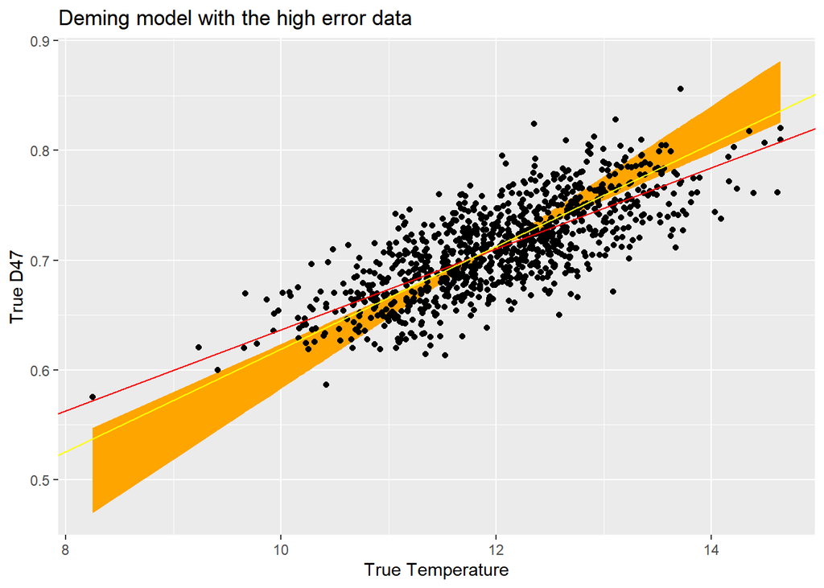

```r
data_high %>%
  ggplot(aes(x = x_TRUE, y=y_TRUE)) +
  geom_ribbon(aes(ymin = 0.0435 * x_TRUE + 0.1889 , ymax = 0.0644   * x_TRUE - 0.0609), fill = "orange") +
  geom_point() +
  geom_abline(slope = 0.0369, intercept = 0.268, color = 'red') +
  geom_abline(slope = median(deming_results_high$t[,2]), intercept = median(deming_results_high$t[,1]), color = 'yellow') +
  labs(title = "Deming model with the high error data") +
  xlab("True Temperature") +
  ylab("True D47")
```

## Median slopes/intercepts VS true parameters

Mean slope/Intercept VS Median slope/Intercept

```r
medianIntercept <- c(median(deming_results_low$t[,1]), median(deming_results_intermediate$t[,1]), median(deming_results_high$t[,1]))
sdIntercept <- c(sd(deming_results_low$t[,1]), sd(deming_results_intermediate$t[,1]), sd(deming_results_high$t[,1]))
medianSlope <- c(median(deming_results_low$t[,2]), median(deming_results_intermediate$t[,2]), median(deming_results_high$t[,2]))
sdSlope <- c(sd(deming_results_low$t[,2]), sd(deming_results_intermediate$t[,2]), sd(deming_results_high$t[,2]))
medianTrainMSE <- c(median(deming_results_low$t[,3]), median(deming_results_intermediate$t[,3]), median(deming_results_high$t[,3]))
medianTestMSE<- c(median(deming_results_low$t[,4]), median(deming_results_intermediate$t[,4]), median(deming_results_high$t[,4]))

mat <- array(c(medianIntercept, sdIntercept, medianSlope, sdSlope, medianTrainMSE, medianTestMSE), dim = c(3, 6))
colnames(mat) <- c("median_Intercept", "sd_Intercept", "median_Slope", "sd_slope", "median_train_MSE", "median_test_MSE")
rownames(mat) <- c("Low Error", "Intermediate Error", "High Error")
mat %>%
  kable()
```

|  | median_Intercept | sd_Intercept | median_Slope | sd_slope | median_train_MSE | median_test_MSE |
| --- | --- | --- | --- | --- | --- | --- |
| Low Error | 0.2096746 | 0.0443952 | 0.0417205 | 0.0037487 | 0.0001978 | 0.0002001 |
| Intermediate Error | 0.2193577 | 0.0598513 | 0.0409306 | 0.0049828 | 0.0006188 | 0.0006253 |
| High Error | 0.1521613 | 0.0577748 | 0.0467426 | 0.0049513 | 0.0013874 | 0.0013984 |